# A Quick Introduction to iNEXT.link via Examples

#### size-based

```r
kable(head(sample2$iNextEst, 5)%>%rbind(tail(sample2$iNextEst, 5)))
```

|  | m | method | Order.q | PD | PD.UCL | PD.LCL | SC | SC.UCL | SC.LCL | Region |
| --- | --- | --- | --- | --- | --- | --- | --- | --- | --- | --- |
| 1 | 1 | interpolated | 0 | 1.000000 | 1.106564 | 0.893436 | 0.1285734 | 0.2481455 | 0.0090013 | Cordillera |
| 2 | 8 | interpolated | 0 | 6.759034 | 7.360717 | 6.157350 | 0.5592674 | 0.6525998 | 0.4659351 | Cordillera |
| 3 | 14 | interpolated | 0 | 10.589446 | 11.478959 | 9.699934 | 0.6841772 | 0.7737454 | 0.5946091 | Cordillera |
| 4 | 20 | interpolated | 0 | 13.802831 | 14.946642 | 12.659020 | 0.7447578 | 0.8253979 | 0.6641177 | Cordillera |
| 5 | 26 | interpolated | 0 | 16.590263 | 17.964470 | 15.216056 | 0.7783049 | 0.8490946 | 0.7075151 | Cordillera |
| 488 | 859 | extrapolated | 2 | 15.426381 | 16.439328 | 14.413435 | 0.9889564 | 1.0082314 | 0.9696814 | Cialitos |
| 489 | 883 | extrapolated | 2 | 15.433434 | 16.447314 | 14.419554 | 0.9893205 | 1.0083108 | 0.9703302 | Cialitos |
| 490 | 908 | extrapolated | 2 | 15.440391 | 16.455192 | 14.425590 | 0.9896869 | 1.0083680 | 0.9710058 | Cialitos |
| 491 | 932 | extrapolated | 2 | 15.446724 | 16.462364 | 14.431084 | 0.9900269 | 1.0084008 | 0.9716530 | Cialitos |
| 492 | 956 | extrapolated | 2 | 15.452744 | 16.469182 | 14.436306 | 0.9903556 | 1.0084140 | 0.9722972 | Cialitos |

- `$AsyEst`: Asymptotic/ Empirical diversity estimates along with confidence intervals and related statistics.

```r
kable(head(sample2$AsyEst,9))
```

| Order.q | Estimate | method | UCL | LCL | Region |
| --- | --- | --- | --- | --- | --- |
| 0 | 41.56250 | Empirical | 46.34709 | 36.77791 | Cordillera |
| 1 | 25.49178 | Empirical | 28.20596 | 22.77760 | Cordillera |
| 2 | 15.99355 | Empirical | 17.94382 | 14.04329 | Cordillera |
| 0 | 77.86137 | Estimate | 88.04230 | 67.68043 | Cordillera |
| 1 | 34.92033 | Estimate | 39.03336 | 30.80730 | Cordillera |
| 2 | 18.25568 | Estimate | 20.78122 | 15.73014 | Cordillera |
| 0 | 51.12500 | Empirical | 56.50954 | 45.74046 | Caguana |
| 1 | 25.42424 | Empirical | 28.62679 | 22.22170 | Caguana |
| 2 | 13.89112 | Empirical | 15.93797 | 11.84427 | Caguana |

### 2. ggiNEXT_PND

To visualize the curves, use `ggiNEXT_PND` to obtain plots based on `ggplot2` package. This function provides three types of curves, which can be specified in the argument `plot.type`:

1. Sample-size-based rarefaction and extrapolation curve (`plot.type = 1`): sampling curve depicting phylogenetic diversity estimates as a function of sample size.
2. Sample completeness curve (`plot.type = 2`): the curve of sample coverage as a function of sample size.
3. Coverage-based R/E curve (`plot.type = 3`): sampling curve depicting Network diversity estimates as a function of sample coverage.

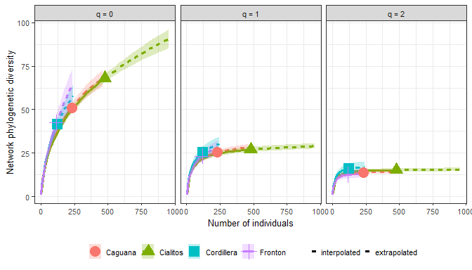

```r
ggiNEXT_PND(sample2, type = 1,facet = "Order.q" )
```

[figure not shown]

```r
ggiNEXT_PND(sample2, type = 3, facet = "Assemblage")
```

### 3. `estimatePND()`

```r
kable(estimatePND(puerto.rico$data, col.tree = coltree, row.tree = rowtree, nboot = 10,datatype="abundance",level=0.7, conf=0.95))
```

| m | method | Order.q | PD | PD.UCL | PD.LCL | SC | SC.UCL | SC.LCL | Assemblage |
| --- | --- | --- | --- | --- | --- | --- | --- | --- | --- |
| 72.99364 | interpolated | 0 | 31.22667 | 34.49570 | 27.95764 | 0.8596624 | 0.8965881 | 0.8227367 | Cordillera |
| 72.99364 | interpolated | 1 | 21.69778 | 23.98432 | 19.41124 | 0.8596624 | 0.8965881 | 0.8227367 | Cordillera |
| 72.99364 | interpolated | 2 | 14.72633 | 16.63291 | 12.81975 | 0.8596624 | 0.8965881 | 0.8227367 | Cordillera |
| 70.95554 | interpolated | 0 | 28.72531 | 30.22521 | 27.22541 | 0.9108105 | 0.9315503 | 0.8900707 | Caguana |
| 70.95554 | interpolated | 1 | 19.16397 | 20.34400 | 17.98394 | 0.9108105 | 0.9315503 | 0.8900707 | Caguana |
| 70.95554 | interpolated | 2 | 12.30488 | 13.24186 | 11.36791 | 0.9108105 | 0.9315503 | 0.8900707 | Caguana |
| 96.75397 | interpolated | 0 | 37.43016 | 41.30952 | 33.55080 | 0.9132282 | 0.9698587 | 0.8565977 | Fronton |
| 96.75397 | interpolated | 1 | 21.76822 | 23.84791 | 19.68853 | 0.9132282 | 0.9698587 | 0.8565977 | Fronton |
| 96.75397 | interpolated | 2 | 12.30736 | 13.62847 | 10.98624 | 0.9132282 | 0.9698587 | 0.8565977 | Fronton |
| 65.59876 | interpolated | 0 | 26.45392 | 27.92286 | 24.98498 | 0.8980296 | 0.9179459 | 0.8781133 | Cialitos |
| 65.59876 | interpolated | 1 | 18.24387 | 19.28818 | 17.19956 | 0.8980296 | 0.9179459 | 0.8781133 | Cialitos |
| 65.59876 | interpolated | 2 | 12.79784 | 13.57756 | 12.01813 | 0.8980296 | 0.9179459 | 0.8781133 | Cialitos |

### 4. Evenness

```r
even2 = NetEvenness(puerto.rico$data, q=  seq(0,2,1), datatype = "abundance", nboot = 0, E = 1:5, method = "Estimated", C = 0.9)
```

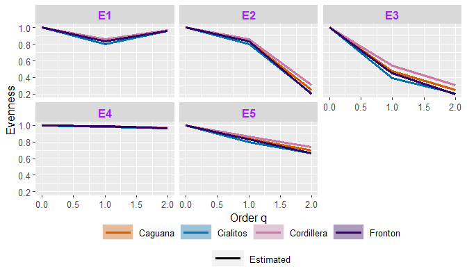

```r
ggNetEven(even2)
```

### 5. Dissimilarity

```r
dissimilarity2 = iNEXT_beta_link(puerto.rico$data, coverage_expected = seq(0.5,1,0.025), data_type='abundance',
                                 q = c(0, 1, 2),level='taxonomic',
                                 row.tree = rowtree,col.tree = coltree,
                                 nboot = 0, conf = 0.95, max_alpha_coverage=F,
                                 by='coverage')
```

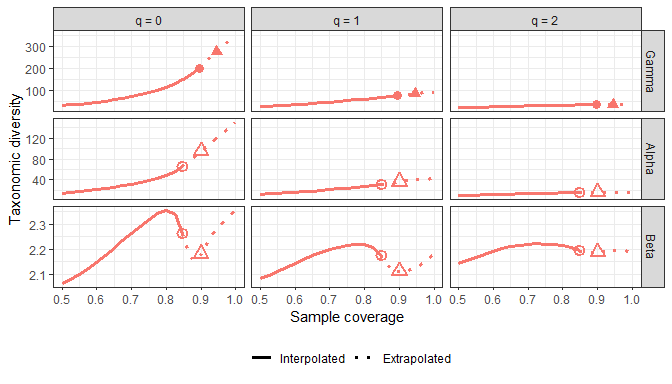

```r
ggiNEXT_beta_link(dissimilarity2, type = 'B')
```

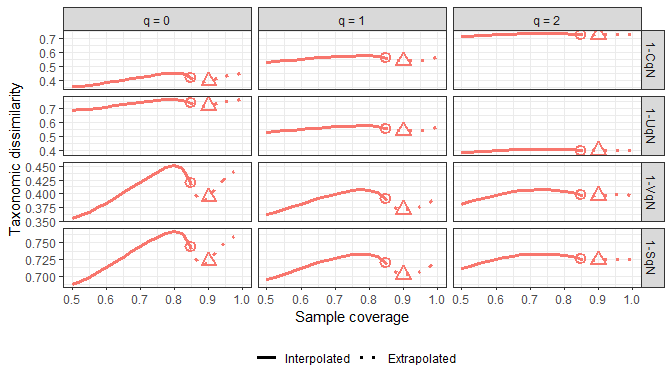

```r
ggiNEXT_beta_link(dissimilarity2, type = 'D')
```

```r
dissimilarity3 = iNEXT_beta_link(x = puerto.rico$data, coverage_expected = seq(0.5,0.99,0.025), data_type='abundance',
                                 q = c(0, 1, 2),level='phylogenetic',
                                 row.tree = rowtree, col.tree = coltree,
                                 nboot = 0, conf = 0.95, max_alpha_coverage=F,
                                 by='coverage')
```

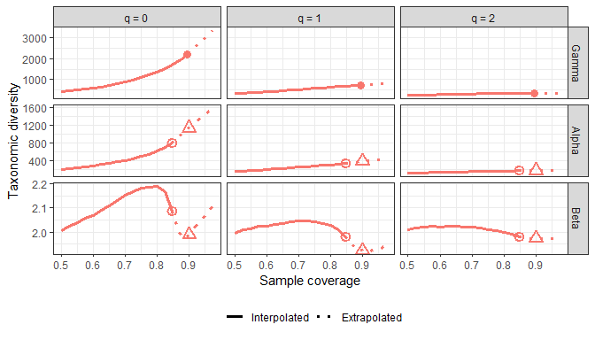

```r
ggiNEXT_beta_link(dissimilarity3, type = 'B')
```

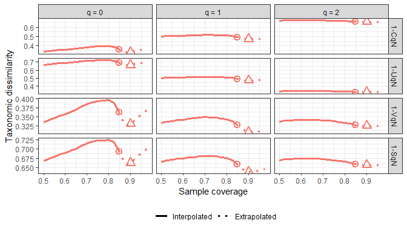

```r
ggiNEXT_beta_link(dissimilarity3, type = 'D')
```

## **License**

The iNEXT.link package is licensed under the GPLv3. To help refine `iNEXT.link`, your comments or feedbacks would be welcome (please send them to Anne Chao).

## **How to cite**

If you publish your work based on results from `iNEXT.link` (R package), please make reference to Chao et al. given in the following list.

## **Reference**

- Chao, A., Chiu C.-H. and Jost, L. (2010). Phylogenetic diversity measures based on Hill numbers. Philosophical Transactions of the Royal Society B., 365, 3599-3609.
- Chao, A., Chiu, C.-H., Hsieh, T. C., Davis, T., Nipperess, D., and Faith, D. (2015) Rarefaction and extrapolation of phylogenetic diversity. Methods in Ecology and Evolution, 6, 380-388.
- Hsieh, T. C. and Chao, A. (2017). Rarefaction and extrapolation: making fair comparison of abundance-sensitive phylogenetic diversity among multiple assemblages. Systematic Biology 66, 100-111.